# Lab 2 Test

Ken Stiller & Felipe Torres

22 January 2020

## Overview

- Introduction
- Natural Experiments
- Recap Last Week
  - Randomization
  - Exercise
- One-Sided Non-Compliance
  - ITT.Y, ITT.D & CACE
- QA

## What Experiment?

You already know various types of experiments, such as survey experiments, lab experiments, field experiments.

How do natural experiments fit in?

- IR: Rotating Presidency of the Council of the EU (Carnegie/Marinov 2017)
- CP: Population size & electoral system (Eggers 2015)
- many others…
- IR/CP: Election Observation (Hyde 2007)

## 1. Data: Election Observation

Today we are using data from Susan Hyde’s work on [**the observer effect in international politics**](https://heinonline.org/HOL/LandingPage?handle=hein.journals/wpot60&div=6&id=&page) in Armenia.

- Research Question: *Do international monitoring missions have an effect on electoral outcomes?*
- Hyde’s reasoning: Cross-sectional comparisons are not suitable as there will be endogeneity
- Hyde’s solution: Moving to the microlevel! (What effect do observers have on election-day fraud?)
  - 2003 Presidential elections in Armenia
- The Experiment: Analysing observed and unobserved polling stations, relying on OSCE missions in terms of incumbent’s vote share
- Outcome: Hyde concludes there was a **5.9%** difference in first round and a **2%** difference in the second round (simple differences in means).

## Let’s check this

- Do we buy that?

What might be the problems associated with this natural experiment?

## Let’s check this

First, as always, we load the file (this time from Stata)…

```r
library(readstata13)
hyde2007 <- read.dta13(file = './hyde2007_uploadR.dta')
```

…and look at the data, that is at some variables of interest:

```r
head(cbind(hyde2007$pollingstation, hyde2007$urban, hyde2007$voterspersqkm, hyde2007$kocharian, hyde2007$mon_voting, hyde2007$mon_voting_R2, hyde2007$KocharianR2, hyde2007$osce_assignment))
```

```
##      [,1]                                   [,2] [,3]
## [1,] "<a0> 1671. Agarak, Club"              "0"  "27.9790992736816"
## [2,] "<a0> 1620. Arevis, School"            "0"  "77.8955993652344"
## [3,] "<a0> 0691. Urtsalanj, School"         "0"  "88.6297988891602"
## [4,] "<a0> 0959. Norabak, secondary School" "0"  "41.4747009277344"
## [5,] "<a0> 1188. Shamlugh, Cultural House"  "0"  "63.1679000854492"
## [6,] "<a0> 0678. Erasghavan, School"        "0"  "88.6297988891602"
##      [,4]                [,5] [,6] [,7]                [,8]
## [1,] "1"                 "1"  "0"  "0.977800011634827" "1"
## [2,] "0.942900002002716" "0"  "0"  "1"                 "1"
## [3,] "0.529999971389771" "1"  "0"  "0.676199972629547" "1"
## [4,] "0.693899989128113" "1"  "0"  "0.868399977684021" "1"
## [5,] "0.506200015544891" "0"  "0"  "0.874300003051758" "1"
## [6,] "0.685899972915649" "1"  "0"  "0.776600062847137" "1"
```

**Exercise**: For the first round results, (i) calculate the difference in means of the incumbent’s vote share (`kocharian`) between observed and unobserved polling stations and (ii) find out whether randomization worked regarding the rural-urban divide (`urban`).

## ATE & Randomization: Round 1

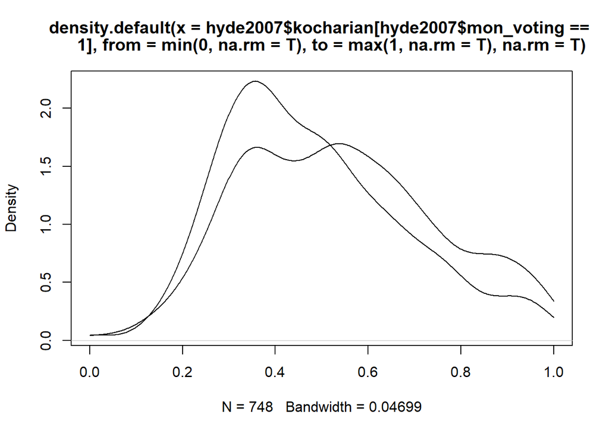

```r
plot(density(hyde2007$kocharian[hyde2007$mon_voting==1], na.rm=T, from=min(0, na.rm=T), to=max(1, na.rm=T)))
lines(density(hyde2007$kocharian[hyde2007$mon_voting==0], na.rm=T, from=min(0, na.rm=T), to=max(1, na.rm=T)))
```

## ATE & Randomization: Round 1

To calculate the difference in means, we could use

- a t.test

```r
t.test(hyde2007$kocharian ~ hyde2007$mon_voting)
```

```
##
##  Welch Two Sample t-test
##
## data:  hyde2007$kocharian by hyde2007$mon_voting
## t = 5.9911, df = 1675.8, p-value = 2.546e-09
## alternative hypothesis: true difference in means is not equal to 0
## 95 percent confidence interval:
##  0.03946639 0.07788563
## sample estimates:
## mean in group 0 mean in group 1
##       0.5419031       0.4832271
```

- an OLS regression

```r
ols1=lm(kocharian ~ mon_voting, data=hyde2007)
summary(ols1)
```

```
##
## Call:
## lm(formula = kocharian ~ mon_voting, data = hyde2007)
##
## Residuals:
##      Min       1Q   Median       3Q      Max
## -0.54190 -0.15898 -0.01937  0.13657  0.51677
##
## Coefficients:
##              Estimate Std. Error t value Pr(>|t|)
## (Intercept)  0.541903   0.006456  83.933  < 2e-16 ***
## mon_voting  -0.058676   0.009915  -5.918 3.91e-09 ***
## ---
## Signif. codes:  0 '***' 0.001 '**' 0.01 '*' 0.05 '.' 0.1 ' ' 1
##
## Residual standard error: 0.2058 on 1762 degrees of freedom
## Multiple R-squared:  0.01949,    Adjusted R-squared:  0.01893
## F-statistic: 35.02 on 1 and 1762 DF,  p-value: 3.908e-09
```

We can do the same (using a prop.test instead of a t.test) in order to check whether randomization worked.

```r
prop.test(table(hyde2007$urban, hyde2007$mon_voting))
```

```
##
##  2-sample test for equality of proportions with continuity correction
##
## data:  table(hyde2007$urban, hyde2007$mon_voting)
## X-squared = 21.088, df = 1, p-value = 4.388e-06
## alternative hypothesis: two.sided
## 95 percent confidence interval:
##  0.06279495 0.15695353
## sample estimates:
##    prop 1    prop 2
## 0.6369427 0.5270684
```

```r
ols_urban=lm(urban ~ mon_voting, data=hyde2007)
summary(ols_urban)
```

```
##
## Call:
## lm(formula = urban ~ mon_voting, data = hyde2007)
##
## Residuals:
##     Min      1Q  Median      3Q     Max
## -0.6190 -0.5079  0.3810  0.4921  0.4921
##
## Coefficients:
##             Estimate Std. Error t value Pr(>|t|)
## (Intercept)  0.50787    0.01550  32.756  < 2e-16 ***
## mon_voting   0.11111    0.02381   4.667 3.29e-06 ***
## ---
## Signif. codes:  0 '***' 0.001 '**' 0.01 '*' 0.05 '.' 0.1 ' ' 1
##
## Residual standard error: 0.4942 on 1762 degrees of freedom
## Multiple R-squared:  0.01221,    Adjusted R-squared:  0.01165
## F-statistic: 21.78 on 1 and 1762 DF,  p-value: 3.294e-06
```

What do we conclude? Do we have reason to think this might affect the validity of the results?

## Round 2

Let’s quickly do the same for Round 2:

```r
ols2=lm(KocharianR2 ~ mon_voting_R2, data=hyde2007)
summary(ols2)
```

```
##
## Call:
## lm(formula = KocharianR2 ~ mon_voting_R2, data = hyde2007)
##
## Residuals:
##      Min       1Q   Median       3Q      Max
## -0.69251 -0.10281 -0.00287  0.11904  0.32733
##
## Coefficients:
##                Estimate Std. Error t value Pr(>|t|)
## (Intercept)    0.692511   0.004781 144.841   <2e-16 ***
## mon_voting_R2 -0.019841   0.008043  -2.467   0.0137 *
## ---
## Signif. codes:  0 '***' 0.001 '**' 0.01 '*' 0.05 '.' 0.1 ' ' 1
##
## Residual standard error: 0.1614 on 1761 degrees of freedom
##   (1 observation deleted due to missingness)
## Multiple R-squared:  0.003444,   Adjusted R-squared:  0.002878
## F-statistic: 6.085 on 1 and 1761 DF,  p-value: 0.01373
```

This looks like a somewhat weaker effect of the observers…

```r
ols2_urban=lm(urban ~ mon_voting_R2, data=hyde2007)
summary(ols2_urban)
```

```
##
## Call:
## lm(formula = urban ~ mon_voting_R2, data = hyde2007)
##
## Residuals:
##     Min      1Q  Median      3Q     Max
## -0.6517 -0.5022  0.3483  0.4978  0.4978
##
## Coefficients:
##               Estimate Std. Error t value Pr(>|t|)
## (Intercept)    0.50219    0.01457  34.473  < 2e-16 ***
## mon_voting_R2  0.14949    0.02451   6.099 1.31e-09 ***
## ---
## Signif. codes:  0 '***' 0.001 '**' 0.01 '*' 0.05 '.' 0.1 ' ' 1
##
## Residual standard error: 0.4921 on 1762 degrees of freedom
## Multiple R-squared:  0.02067,    Adjusted R-squared:  0.02012
## F-statistic: 37.19 on 1 and 1762 DF,  p-value: 1.313e-09
```

Round 2 seems to be even less balanced in terms of the representation of urban and rural polling stations.

- What else could be relevant in Round 2? Why should we account for this?

## Round 2

- Hyde concludes that her *“results suggest that if first-round monitoring took place then second-round monitoring had only a marginal additional deterrent effect.”* (p.56). She claims that first-round observation has a persistant effect.
- Your thoughts on this?

Let’s see whether monitoring in the two rounds was independent. First, we check the number of polling stations observed per round.

```r
sum(with(hyde2007, mon_voting==0 & mon_voting_R2==0))
```

```
## [1] 756
```

```r
sum(with(hyde2007, mon_voting==1 & mon_voting_R2==0))
```

```
## [1] 385
```

```r
sum(with(hyde2007, mon_voting==0 & mon_voting_R2==1))
```

```
## [1] 260
```

```r
sum(with(hyde2007, mon_voting==1 & mon_voting_R2==1))
```

```
## [1] 363
```

Well, in Round 2 more stations were observed that had been monitored in Round 1 than those that had not been monitored. Let’s confirm significance.

```r
prop.test(table(hyde2007$mon_voting_R2, hyde2007$mon_voting))
```

```
##
##  2-sample test for equality of proportions with continuity correction
##
## data:  table(hyde2007$mon_voting_R2, hyde2007$mon_voting)
## X-squared = 98.233, df = 1, p-value < 2.2e-16
## alternative hypothesis: two.sided
## 95 percent confidence interval:
##  0.1965443 0.2939381
## sample estimates:
##    prop 1    prop 2
## 0.6625767 0.4173355
```

```r
ols2_full=lm(mon_voting_R2 ~ urban + mon_voting, data=hyde2007)
summary(ols2_full)
```

```
##
## Call:
## lm(formula = mon_voting_R2 ~ urban + mon_voting, data = hyde2007)
##
## Residuals:
##     Min      1Q  Median      3Q     Max
## -0.5289 -0.3122 -0.1978  0.4711  0.8022
##
## Coefficients:
##             Estimate Std. Error t value Pr(>|t|)
## (Intercept)  0.19777    0.01836  10.774  < 2e-16 ***
## urban        0.11447    0.02223   5.148 2.92e-07 ***
## mon_voting   0.21667    0.02236   9.690  < 2e-16 ***
## ---
## Signif. codes:  0 '***' 0.001 '**' 0.01 '*' 0.05 '.' 0.1 ' ' 1
##
## Residual standard error: 0.4613 on 1761 degrees of freedom
## Multiple R-squared:  0.07025,    Adjusted R-squared:  0.06919
## F-statistic: 66.53 on 2 and 1761 DF,  p-value: < 2.2e-16
```

What do we conclude?

- Round 2 monitoring was not randomized either.
- If we apply experimental standards (which is what we should do), we conclude that Round 2 monitoring was not independent from Round 1 monitoring.

## 2. Non-Compliance

One of the reasons for the imbalance between rural and urban polling station could be that observers did not adhere to their assigned polling stations. Let’s now assume, the OSCE did a good job and assigned polling stations randomly (`osce_assignment`).

In that case, one-sided **non-compliance** would be a problem. Some polling stations that were supposed to be monitored were, in fact, not monitored on election day. Let’s check Hyde’s results once we consider non-compliance to be a problem

```r
attach(hyde2007) # it helps to avoid using the dollar sign
```

Let’s start with a (some naive) simple differences in means:

```r
#As-treated Analysis
(mean(KocharianR2[mon_voting_R2==1], na.rm = TRUE) - mean(KocharianR2[mon_voting_R2==0], na.rm = TRUE))
```

```
## [1] -0.01984091
```

```r
library(tidyverse)
hyde2007 <- hyde2007 %>%  # remove any NAs
  drop_na(KocharianR2)
```

Let’s look at a simple crosstab, showing assigned treatment and actual treatment.

```r
#Compliance Status - Binary
tab.1 <- table(osce_assignment, mon_voting_R2)
print(tab.1)
```

```
##                mon_voting_R2
## osce_assignment   0   1
##               0 883   0
##               1 258 623
```

Now, we calculate the `ITT.y`. We can do this using differences in means or simply running an OLS.

```r
#ITT_Y
itt.y <- (mean(KocharianR2[osce_assignment==1], na.rm = TRUE) - mean(KocharianR2[osce_assignment==0], na.rm = TRUE))
itt.y
```

```
## [1] -0.01544005
```

```r
# ITT_Y using OLS
library(sandwich)
library(lmtest)
itt_fit <- lm(KocharianR2 ~ osce_assignment)
summary(itt_fit)
```

```
##
## Call:
## lm(formula = KocharianR2 ~ osce_assignment)
##
## Residuals:
##      Min       1Q   Median       3Q      Max
## -0.69322 -0.10448 -0.00248  0.11818  0.32222
##
## Coefficients:
##                  Estimate Std. Error t value Pr(>|t|)
## (Intercept)      0.693215   0.005439 127.456   <2e-16 ***
## osce_assignment -0.015440   0.007694  -2.007   0.0449 *
## ---
## Signif. codes:  0 '***' 0.001 '**' 0.01 '*' 0.05 '.' 0.1 ' ' 1
##
## Residual standard error: 0.1615 on 1761 degrees of freedom
##   (1 observation deleted due to missingness)
## Multiple R-squared:  0.002282,   Adjusted R-squared:  0.001715
## F-statistic: 4.027 on 1 and 1761 DF,  p-value: 0.04492
```

```r
#coeftest(itt_fit, vcovHC(itt_fit))  # Heteroscedasticity-Consistent Covariance Matrix Estimation-Consistent Covariance
```

Accordingly, we calculate the ITT.d

```r
#ITT_D
itt.d <- (mean(mon_voting_R2[osce_assignment==1], na.rm = TRUE) - mean(mon_voting_R2[osce_assignment==0], na.rm = TRUE))
itt.d
```

```
## [1] 0.707151
```

```r
## ITT_D using OLS
itt_d_fit <- lm(mon_voting_R2 ~ osce_assignment)
summary(itt_d_fit)
```

```
##
## Call:
## lm(formula = mon_voting_R2 ~ osce_assignment)
##
## Residuals:
##     Min      1Q  Median      3Q     Max
## -0.7071  0.0000  0.0000  0.2928  0.2928
##
## Coefficients:
##                  Estimate Std. Error t value Pr(>|t|)
## (Intercept)     1.565e-15  1.083e-02    0.00        1
## osce_assignment 7.072e-01  1.532e-02   46.15   <2e-16 ***
## ---
## Signif. codes:  0 '***' 0.001 '**' 0.01 '*' 0.05 '.' 0.1 ' ' 1
##
## Residual standard error: 0.3218 on 1762 degrees of freedom
## Multiple R-squared:  0.5473, Adjusted R-squared:  0.547
## F-statistic:  2130 on 1 and 1762 DF,  p-value: < 2.2e-16
```

```r
# coeftest(itt_d_fit, vcovHC(itt_d_fit)) # Heteroscedasticity-Consistent Covariance Matrix Estimation
```

Let’s quickly have a look at the compliance status and the broad picture.

```r
#Let's remember the compliance status [1] 883 [2]258 [3] 0 [4]623
tab.1 <- table(osce_assignment, mon_voting_R2)
print(tab.1)
```

```
##                mon_voting_R2
## osce_assignment   0   1
##               0 883   0
##               1 258 623
```

```r
#Always-Takers
# Under one-sided non-compliance there are no Always takers, so this should be zero
# 0 / (883 + 0) = 0
at <- tab.1[3]/(tab.1[1] + tab.1[3])
at
```

```
## [1] 0
```

```r
#Never Takers
# 258/(258 + 623) = 0.29
# This means that from those polling stations that were assigned to treatment, 29% will not be monitored
nt <- tab.1[2]/(tab.1[2] + tab.1[4])
nt
```

```
## [1] 0.292849
```

```r
#Compliers (No Defiers By Assumption)
1 - at - nt
```

```
## [1] 0.707151
```

Finally, using the `ITT.y` and the `ITT.d` , we can calculate the CACE:

```r
#CACE: ITT_Y divided by ITT_D # COMPLIER AVERAGE CAUSAL EFFECT
(mean(KocharianR2[osce_assignment==1], na.rm = TRUE) - mean(KocharianR2[osce_assignment==0], na.rm = TRUE))/(mean(mon_voting_R2[osce_assignment==1], na.rm = TRUE) - mean(mon_voting_R2[osce_assignment==0], na.rm = TRUE))
```

```
## [1] -0.02183417
```

```r
cace <- itt.y/itt.d # This should be the same!
print(cace)
```

```
## [1] -0.02183417
```

We can also calculate the significance of the CACE. To do so, we calculate the standard errors of the CACE (this is in fact, an approximation):

`SE(CACE)` $\approx$ `SE(ITT.Y) / ITT.D`

```r
se_cace <- summary(itt_fit)$coefficients[4]/itt_d_fit$coefficients
print(se_cace)
```

```
##     (Intercept) osce_assignment
##    4.916583e+12    1.088013e-02
```

We then calculate the p-value as we did last week:

```r
t_cace <- cace / se_cace
print(t_cace)
```

```
##     (Intercept) osce_assignment
##   -4.440922e-15   -2.006793e+00
```

```r
p <- (1 - pnorm(abs(t_cace), 0, 1)) * 2
p
```

```
##     (Intercept) osce_assignment
##      1.00000000      0.04477166
```

As we will be seeing in a few weeks time, we can also use 2SLS regressions to calculate the CACE.

```r
library(AER)
#Via TSLS
summary(ivreg(KocharianR2 ~ mon_voting_R2|osce_assignment, data=hyde2007))
```

```
##
## Call:
## ivreg(formula = KocharianR2 ~ mon_voting_R2 | osce_assignment,
##     data = hyde2007)
##
## Residuals:
##       Min        1Q    Median        3Q       Max
## -0.693215 -0.103031 -0.002715  0.118335  0.328619
##
## Coefficients:
##                Estimate Std. Error t value Pr(>|t|)
## (Intercept)    0.693215   0.005436 127.528   <2e-16 ***
## mon_voting_R2 -0.021834   0.010874  -2.008   0.0448 *
## ---
## Signif. codes:  0 '***' 0.001 '**' 0.01 '*' 0.05 '.' 0.1 ' ' 1
##
## Residual standard error: 0.1614 on 1761 degrees of freedom
## Multiple R-Squared: 0.003409,    Adjusted R-squared: 0.002843
## Wald test: 4.032 on 1 and 1761 DF,  p-value: 0.0448
```

## So?

- What do we make of Susan Hyde’s paper?
- Is this a “bad” experiment? Why?
- Can there be “perfect” natural experiments?